# Session 9

## Learning objectives

- Pie and stacked bar plots
- Bar plots
- Strip charts
- Box plots

Perhaps the biggest problem we currently have in representing microbial ecology data today is finding an effective method of representing the relative abundances of individual OTUs and taxa. The two most common approaches are pie and stacked barplots. Others prefer methods we’ve already seen - strip, bar, and box plots. In this session we’ll build a few of these plots using phylum and OTU-level data. We’ll build off of the code you compiled together in the commenting activity from the previous session.

One significant problem with pie and stacked bar charts is that the number of proportions you can represent *should* be rather limited. If we want to represent OTU data in a pie chart we would need hundreds of wedges. That would be a pain. Using the `mean_phylum_matrix` object from the previous session, we’ll build some pie and bar plots to make a few points. Having already seen a a number of R plotting commands, the syntax for a pie chart is relatively straightforward.

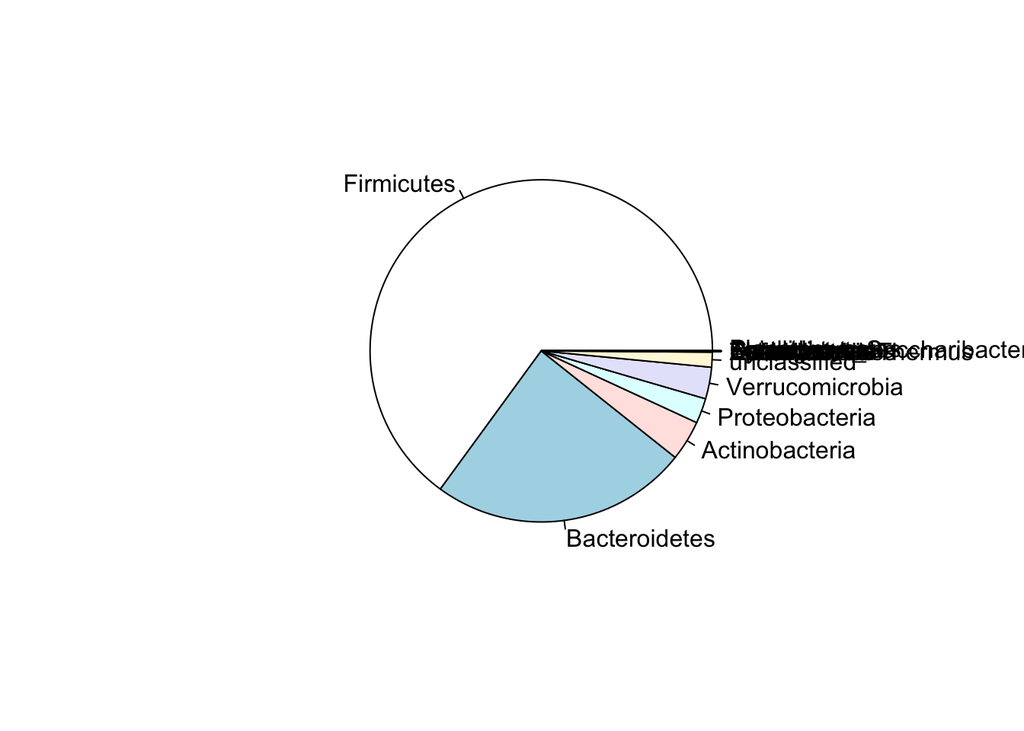

```r
source("code/baxter.R")
metadata <- get_meta()

count_phyla <- function(phylum, otu_counts, map){
    otus <- map[map$phylum == phylum, 'otu']
    sub_shared <- otu_counts[,otus]

    if(length(otus) > 1){
        phylum_count <- apply(sub_shared, 1, sum)
    } else {
        phylum_count <- sub_shared
    }
    return(phylum_count)
}

taxonomy <- read.table(file="data/baxter.cons.taxonomy", header=T, stringsAsFactors=F)
tax_no_confidence <- gsub(pattern="\\(\\d*\\)", replacement="", x=taxonomy$Taxonomy)
phylum <- gsub("Bacteria;([^;]*);.*", "\\1", tax_no_confidence)
otu_phylum <- data.frame(otu = taxonomy$OTU, phylum = phylum, stringsAsFactors=F)

shared <- read.table(file="data/baxter.subsample.shared", header=T, stringsAsFactors=F, row.names=2)
shared <- shared[,-c(1,2)]

otu_phylum_overlap <- otu_phylum[otu_phylum$otu %in% colnames(shared), ]
stopifnot(nrow(otu_phylum_overlap) == ncol(shared))

unique_phyla <- unique(otu_phylum_overlap$phylum)

phylum_shared <- sapply(X=unique_phyla, FUN=count_phyla, otu_counts=shared, map=otu_phylum_overlap)

n_seqs <- apply(phylum_shared, 1, sum)
rel_abund <- phylum_shared / n_seqs

median_rel_abund <- apply(rel_abund, 2, median)
decreasing_order <- order(median_rel_abund, decreasing=T)
rel_abund <- rel_abund[,decreasing_order]

mean_phylum <- aggregate(rel_abund, by=list(metadata$dx), mean)
mean_phylum_matrix <- as.matrix(t(mean_phylum[,-1]))
colnames(mean_phylum_matrix) <- mean_phylum$Group.1

sd_phylum <- aggregate(rel_abund, by=list(metadata$dx), sd)
sd_phylum_matrix <- as.matrix(t(sd_phylum[,-1]))
colnames(sd_phylum_matrix) <- sd_phylum$Group.1

stopifnot(metadata$sample == rownames(rel_abund))

pie(mean_phylum_matrix[,"normal"])
pie(mean_phylum_matrix[,"normal"])
```

```r
pie(mean_phylum_matrix[,"normal"])
```

You could add the `col` argument to provide a different color scheme or aggregate those phyla that have a relative abundance less than 0.02 into an “Other” category. We’ll leave that to you to practice your R skills. At this point you have seen everything you would need to pull this off. Regardless, the pie charts are going to be problematic - we’ll come back to this in a moment.

Let’s see an alternative way to represent relative abundance data using relative areas - stacked bar plots. We’ve previously seen how to generate bar plots when we were plotting alpha diversity data. When we used `barplot` previously, we used `beside=T` to plot the bars next to each other. If we instead use `beside=F`, which is the default, we get a stacked bar plot.

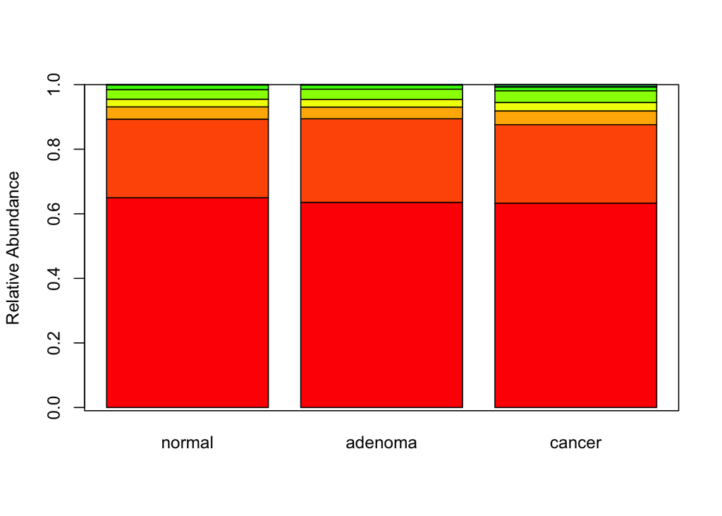

```r
barplot(mean_phylum_matrix, beside=F, col=rainbow(n=nrow(mean_phylum_matrix)), ylab="Relative Abundance")
box()
```

I don’t want to spend a lot of time on the various parameters that are available for pie and stacked bar plots. They’re a data visualization eyesore that both suffer from the same problems. If you run `?pie` You’ll find the following gem in the Note section…

> ```
>  Pie charts are a very bad way of displaying information.  The eye
>  is good at judging linear measures and bad at judging relative
>  areas.  A bar chart or dot chart is a preferable way of displaying
>  this type of data.
>
>  Cleveland (1985), page 264: “Data that can be shown by pie charts
>  always can be shown by a dot chart.  This means that judgements of
>  position along a common scale can be made instead of the less
>  accurate angle judgements.” This statement is based on the
>  empirical investigations of Cleveland and McGill as well as
>  investigations by perceptual psychologists.
> ```

That’s a justification based on our inability to perceive areas. But what else is wrong with pie and stacked bar plots? As we can see, even for phylum-level data, there are way too many wedges/bars to represent with a small number of colors. This makes it difficult to pick contrasting colors. A bigger problem is the inability to represent the variation in the relative abundances. In the following sessions we’ll cover better ways of comparing relative abundance data.

Let’s start by making a bar plot but by plotting the bars next to each other. We’ll use the same syntax as above, but use `beside=T`

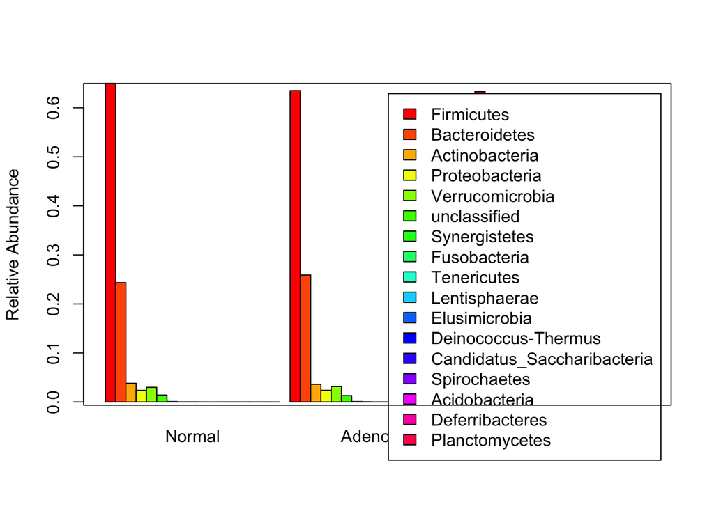

```r
barplot(mean_phylum_matrix, beside=T, col=rainbow(n=nrow(mean_phylum_matrix)), names.arg=c("Normal", "Adenoma", "Cancer"), legend=T, ylab="Relative Abundance")
box()
```

In this plot we’ve grouped the bars by diagnosis, perhaps we’d like to instead highlight the differences between the diasnoses, rather than the phyla. If we transpose `mean_phylum_matrix` we can do this. To transpose a matrix we will use the `t` function like so

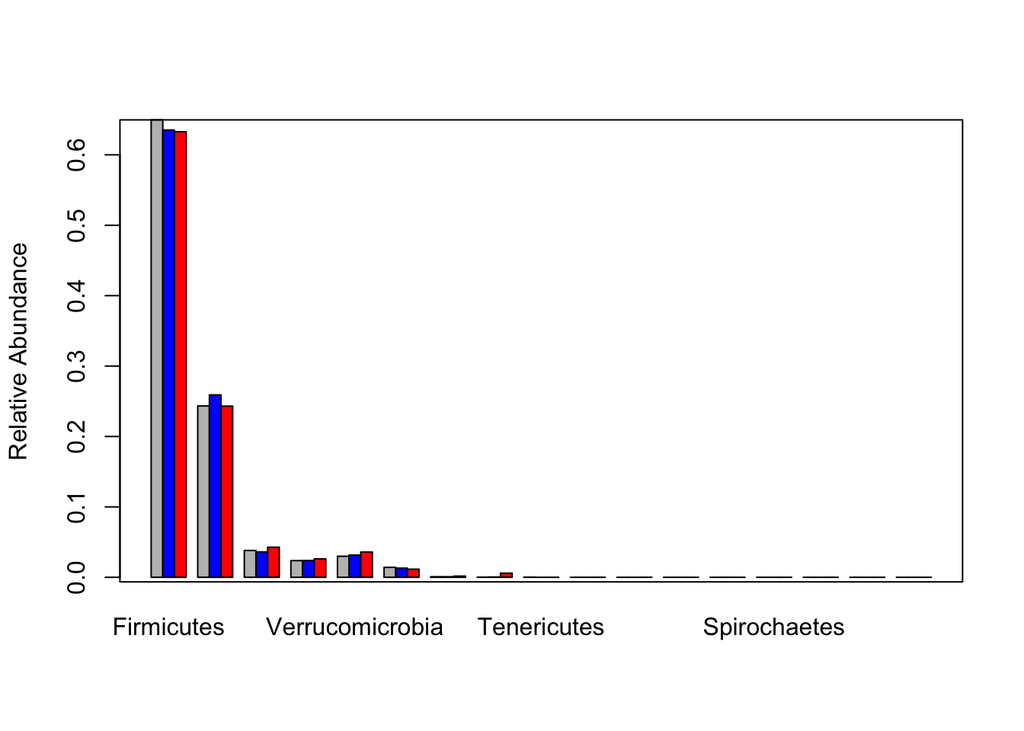

```r
barplot(t(mean_phylum_matrix), beside=T, col=c("gray", "blue", "red"), ylab="Relative Abundance")
box()
```

That’s better, but we have a number of phyla on there that really aren’t very helpful because they were so rare. Let’s remove anything that was below 2% relative abundance. Can you fill in the missing information below to limit the number of phyla we’ll plot?

```r
abundant <- apply(?????, ?????, mean) > ????
mean_abundant_phylum_matrix <- mean_phylum_matrix[abundant, ]

barplot(t(mean_abundant_phylum_matrix), beside=T, col=c("gray", "blue", "red"), ylab="Relative Abundance")
box()
```

Let’s add some error bars to these and we’ll plot the standard deviations that we calculated earlier and stored in `sd_phylum_matrix`. Eventually, we probably would rather use the 95% confidence interval, but we aren’t quite ready for that yet and this will give us some immediate practice using the `arrows` function. Recall that we need to call `barplot` and assign the output to a variable so we get the x-axis positions. We’ll see that the tips of the error bars go beyond the y-axis limits so go ahead and adjust those.

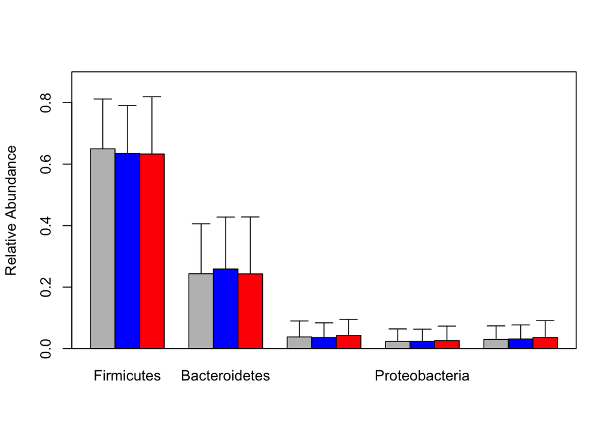

```r
abundant <- apply(mean_phylum_matrix, 1, mean) > 0.02
mean_abundant_phylum_matrix <- mean_phylum_matrix[abundant, ]
sd_abundant_phylum_matrix <- sd_phylum_matrix[abundant, ]

bp <- barplot(t(mean_abundant_phylum_matrix), beside=T, col=c("gray", "blue", "red"), ylab="Relative Abundance", ylim=c(0,0.9))

arrows(x0=bp, y0=t(mean_abundant_phylum_matrix), y1=t(mean_abundant_phylum_matrix+sd_abundant_phylum_matrix), angle=90, length=0.1)
box()
```

Cool, eh? This is already far more informative than the pie or stacked bar plots that we had in the previous lesson. A problem with bar plots is that they hide the true distribution of the data. To get a better sense of their distribution, we could use a box plot. Here’s a set of box plots for the first phylum.

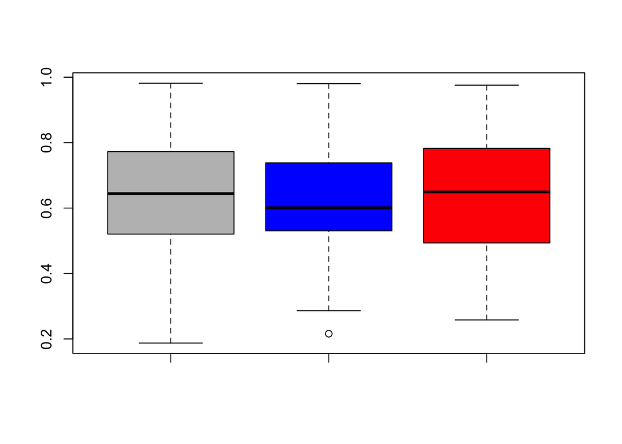

```r
boxplot(rel_abund[,1]~metadata$dx, col=c("gray", "blue", "red"), names=F)
```

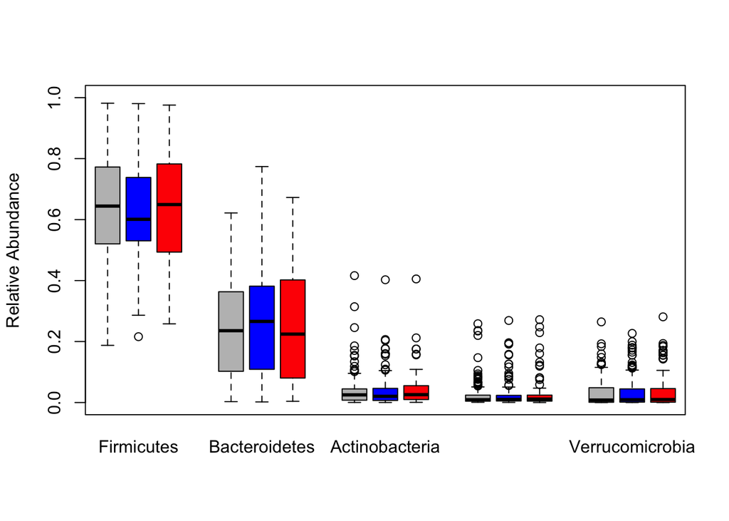

```r
plot(NA, ylim=c(0,1), xlim=c(1,19), ylab="Relative Abundance", xlab="", axes=F)
boxplot(rel_abund[,1]~metadata$dx, at=1:3, names=F, add=T, axes=F, col=c("gray", "blue", "red"))
boxplot(rel_abund[,2]~metadata$dx, at=5:7, names=F, add=T, axes=F, col=c("gray", "blue", "red"))
boxplot(rel_abund[,3]~metadata$dx, at=9:11, names=F, add=T, axes=F, col=c("gray", "blue", "red"))
boxplot(rel_abund[,4]~metadata$dx, at=13:15, names=F, add=T, axes=F, col=c("gray", "blue", "red"))
boxplot(rel_abund[,5]~metadata$dx, at=17:19, names=F, add=T, axes=F, col=c("gray", "blue", "red"))
axis(1, labels=colnames(rel_abund)[1:5], at=c(2,6,10, 14,18), tick=F)
axis(2)
box()
```

One cool trick we were able to use with this plot was to draw the axes separately from the original plot. This is a useful trick if you want to force certain tick marks or you want to have a specific formatting. For example, back on our rarefaction plot we may have wanted to use a “,” to separate the thousands units. Here we would like to reformat our y-axis labels so that “0.2” shows up as “20” so we can express our relative abundances as a percentage rather than as a fraction. Think you can figure it out? One other thing to try is use `las=2` in your `axis(2, ...)` function call.

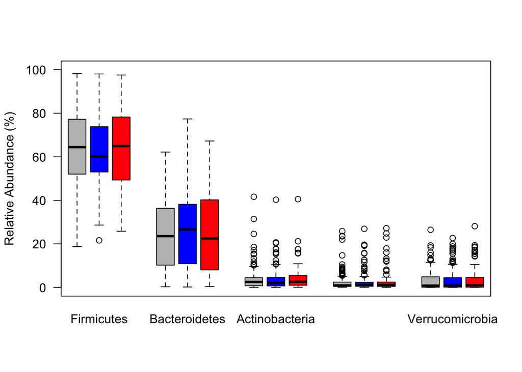

```r
plot(NA, ylim=c(0,1), xlim=c(1,19), ylab="Relative Abundance (%)", xlab="", axes=F)
boxplot(rel_abund[,1]~metadata$dx, at=1:3, names=F, add=T, axes=F, col=c("gray", "blue", "red"))
boxplot(rel_abund[,2]~metadata$dx, at=5:7, names=F, add=T, axes=F, col=c("gray", "blue", "red"))
boxplot(rel_abund[,3]~metadata$dx, at=9:11, names=F, add=T, axes=F, col=c("gray", "blue", "red"))
boxplot(rel_abund[,4]~metadata$dx, at=13:15, names=F, add=T, axes=F, col=c("gray", "blue", "red"))
boxplot(rel_abund[,5]~metadata$dx, at=17:19, names=F, add=T, axes=F, col=c("gray", "blue", "red"))
axis(1, labels=colnames(rel_abund)[1:5], at=c(2,6,10, 14,18), tick=F)
axis(2, at=seq(0,1,0.2), label=seq(0,100, 20), las=2)
box()
```

### Activity 1

If you change the size of the window by dragging the lower right corner to the left, do you notice that some of our phylum names go away? This is less than ideal. We just saw how we could use the `las` argument to turn the labels 90 degrees. What happens when you use `las=2` in your `axis(1, ...)` function call? Modify the margins so that the names fit in the plotting window.

### Activity 2

Hopefully you’re keyed into the fact that this code is not DRY. It also doesn’t lend itself very well to incorporating new data or should we want to adjust our minimal threshold. Rewrite the code to replace the five `boxplot` function calls with a single cal within a for loop and filter the `rel_abund` matrix to those phyla whose average relative abundance is greater than 2%. Finally, add a legend to the plot.

A box plot is an effective way to show the shape of the distribution for each of your phyla if you have a lot of data. If you don’t have a lot of points, it can be a bit deceiving. Also, the default whisker placement on the box plot is 1.5 times the size of the box, which represents the quartiles. I prefer to see my data, rather than mask it with boxes and whiskers. To do that we’ll move to a strip chart. As we’ve already seen, the advantage of a strip chart is that we can show all of the data. The downside is that over plotting can obscure our sense of the true distribution of the data. Our syntax will be similar to what we’ve already done with the box plot.

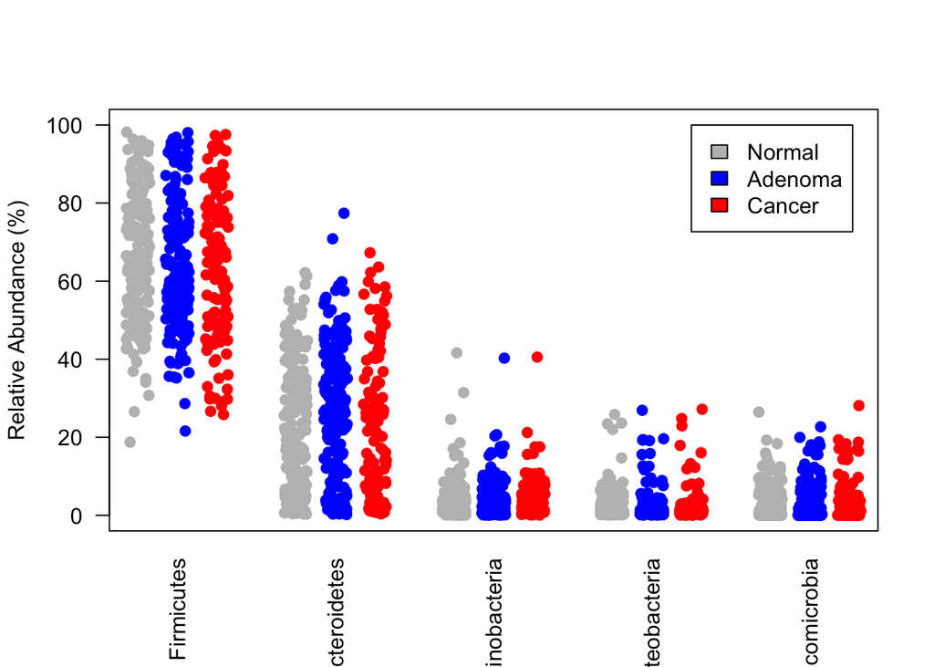

```r
abundant <- apply(mean_phylum_matrix, 1, mean) > 0.02
ab_rel_abund <- rel_abund[,abundant]

plot(NA, ylim=c(0,1), xlim=c(1,19), ylab="Relative Abundance (%)", xlab="", axes=F)

start <- 1
end <- 3

for(otu in 1:ncol(ab_rel_abund)){
    stripchart(ab_rel_abund[,otu]~metadata$dx, at=start:end, add=T, vertical=T, method="jitter", jitter=0.3, axes=F, col=c("gray", "blue", "red"), pch=19)
    start <- start + 4
    end <- end + 4
}

axis(1, labels=colnames(ab_rel_abund), at=c(2,6,10, 14,18), tick=F, las=2)
axis(2, at=seq(0,1,0.2), label=seq(0,100, 20), las=2)
box()

legend(x=15, y=1, legend=c("Normal", "Adenoma", "Cancer"), fill=c("gray", "blue", "red"))
```

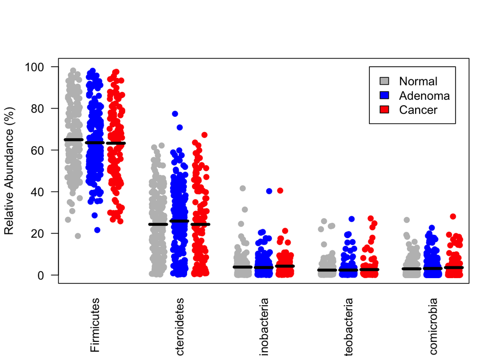

```r
abundant <- apply(mean_phylum_matrix, 1, mean) > 0.02
ab_rel_abund <- rel_abund[,abundant]

plot(NA, ylim=c(0,1), xlim=c(1,19), ylab="Relative Abundance (%)", xlab="", axes=F)

start <- 1
end <- 3

for(otu in 1:ncol(ab_rel_abund)){
    stripchart(ab_rel_abund[,otu]~metadata$dx, at=start:end, add=T, vertical=T, method="jitter", jitter=0.3, axes=F, col=c("gray", "blue", "red"), pch=19)

    segments(x0=(start:end)-0.4, x1=(start:end)+0.4, y0=mean_abundant_phylum_matrix[otu,], lwd=4)
    start <- start + 4
    end <- end + 4
}

axis(1, labels=colnames(ab_rel_abund), at=c(2,6,10, 14,18), tick=F, las=2)
axis(2, at=seq(0,1,0.2), label=seq(0,100, 20), las=2)
box()

legend(x=15, y=1, legend=c("Normal", "Adenoma", "Cancer"), fill=c("gray", "blue", "red"))
```

### Activity 3

We frequently want to italicize taxonomic names. Journals vary in their styles, but the ASM journals ask that tall taxonomic names be italicized. In the `axis` function call that you used to generate the phylum names use the `font` argument and give it values of 1, 2, 3, and 4. What do you get for each? Which is the preferred value?

### Activity 4

Sometimes it’s easier to visualize a plot if it is rotated 90 degrees. Can you transpose the strip chart so the strips go from left to right? What happens if you set the y-axis limits from 19 to 1 instead of from 1 to 19?